# Project Foundations for Data Science: FoodHub Data Analysis

**Marks: 60**

### Context

The number of restaurants in New York is increasing day by day. Lots of students and busy professionals rely on those restaurants due to their hectic lifestyles. Online food delivery service is a great option for them. It provides them with good food from their favorite restaurants. A food aggregator company FoodHub offers access to multiple restaurants through a single smartphone app.

The app allows the restaurants to receive a direct online order from a customer. The app assigns a delivery person from the company to pick up the order after it is confirmed by the restaurant. The delivery person then uses the map to reach the restaurant and waits for the food package. Once the food package is handed over to the delivery person, he/she confirms the pick-up in the app and travels to the customer's location to deliver the food. The delivery person confirms the drop-off in the app after delivering the food package to the customer. The customer can rate the order in the app. The food aggregator earns money by collecting a fixed margin of the delivery order from the restaurants.

### Objective

The food aggregator company has stored the data of the different orders made by the registered customers in their online portal. They want to analyze the data to get a fair idea about the demand of different restaurants which will help them in enhancing their customer experience. Suppose you are hired as a Data Scientist in this company and the Data Science team has shared some of the key questions that need to be answered. Perform the data analysis to find answers to these questions that will help the company to improve the business.

### Data Description

The data contains the different data related to a food order. The detailed data dictionary is given below.

### Data Dictionary

- order_id: Unique ID of the order
- customer_id: ID of the customer who ordered the food
- restaurant_name: Name of the restaurant
- cuisine_type: Cuisine ordered by the customer
- cost: Cost of the order
- day_of_the_week: Indicates whether the order is placed on a weekday or weekend (The weekday is from Monday to Friday and the weekend is Saturday and Sunday)
- rating: Rating given by the customer out of 5
- food_preparation_time: Time (in minutes) taken by the restaurant to prepare the food. This is calculated by taking the difference between the timestamps of the restaurant's order confirmation and the delivery person's pick-up confirmation.
- delivery_time: Time (in minutes) taken by the delivery person to deliver the food package. This is calculated by taking the difference between the timestamps of the delivery person's pick-up confirmation and drop-off information

### Let us start by importing the required libraries

```python
# import libraries for data manipulation
import numpy as np
import pandas as pd

# import libraries for data visualization
import matplotlib.pyplot as plt
import seaborn as sns
```

### Understanding the structure of the data

```python
# read the data
df = pd.read_csv('foodhub_order.csv')
# returns the first 5 rows
df.head()
```

|  | order_id | customer_id | restaurant_name | cuisine_type | cost_of_the_order | day_of_the_week | rating | food_preparation_time | delivery_time |
| --- | --- | --- | --- | --- | --- | --- | --- | --- | --- |
| 0 | 1477147 | 337525 | Hangawi | Korean | 30.75 | Weekend | Not given | 25 | 20 |
| 1 | 1477685 | 358141 | Blue Ribbon Sushi Izakaya | Japanese | 12.08 | Weekend | Not given | 25 | 23 |
| 2 | 1477070 | 66393 | Cafe Habana | Mexican | 12.23 | Weekday | 5 | 23 | 28 |
| 3 | 1477334 | 106968 | Blue Ribbon Fried Chicken | American | 29.20 | Weekend | 3 | 25 | 15 |
| 4 | 1478249 | 76942 | Dirty Bird to Go | American | 11.59 | Weekday | 4 | 25 | 24 |

#### Observations:

The DataFrame has 9 columns as mentioned in the Data Dictionary. Data in each row corresponds to the order placed by a customer.

### **Question 1:** How many rows and columns are present in the data? [0.5 mark]

```python
#printing shape of the dataframe
print(df.shape)
```

```
(1898, 9)
```

#### Observations:

There are 1898 rows and 9 columns present in the dataset

### **Question 2:** What are the datatypes of the different columns in the dataset? (The info() function can be used) [0.5 mark]

```python
# Using info function to print summary of dataframe
print(df.info())
```

```
<class 'pandas.core.frame.DataFrame'>
RangeIndex: 1898 entries, 0 to 1897
Data columns (total 9 columns):
 #   Column                 Non-Null Count  Dtype
---  ------                 --------------  -----
 0   order_id               1898 non-null   int64
 1   customer_id            1898 non-null   int64
 2   restaurant_name        1898 non-null   object
 3   cuisine_type           1898 non-null   object
 4   cost_of_the_order      1898 non-null   float64
 5   day_of_the_week        1898 non-null   object
 6   rating                 1898 non-null   object
 7   food_preparation_time  1898 non-null   int64
 8   delivery_time          1898 non-null   int64
dtypes: float64(1), int64(4), object(4)
memory usage: 133.6+ KB
None
```

#### Observations:

Based on the output from the info function, there are 4 int columns, 1 float column, and 4 object columns.

### **Question 3:** Are there any missing values in the data? If yes, treat them using an appropriate method. [1 mark]

```python
#printing summary table of null values
print(df.isnull().sum())
```

```
order_id                 0
customer_id              0
restaurant_name          0
cuisine_type             0
cost_of_the_order        0
day_of_the_week          0
rating                   0
food_preparation_time    0
delivery_time            0
dtype: int64
```

#### Observations:

There are no null values in the dataset - therefore it's not necessary to fill or drop any rows.

### **Question 4:** Check the statistical summary of the data. What is the minimum, average, and maximum time it takes for food to be prepared once an order is placed? [2 marks]

```python
#describing only the food_preparation_time column
print(df['food_preparation_time'].describe())
```

```
count    1898.000000
mean       27.371970
std         4.632481
min        20.000000
25%        23.000000
50%        27.000000
75%        31.000000
max        35.000000
Name: food_preparation_time, dtype: float64
```

#### Observations:

Based on the output from the describe function on the food_preparation_time column, we can extract the following insights (including both the mean and median food preparation times):

- minimum preparation time is 20 minutes
- maximum preparation time is 35 minutes
- mean preparation time is 27.37 minutes
- median preparation time is 27 minutes

### **Question 5:** How many orders are not rated? [1 mark]

```python
#summing the number of rows in the dataframe where rating is not given
total_count = ((df['rating']=='Not given').sum())

#calculating as a percentage
percent_count = round(100*((df['rating']=='Not given').mean()),2)

#printing answers in context
print(f"total orders with no rating given: {total_count}")
print(f"percentage of no rating orders: {percent_count}%")
```

```
total orders with no rating given: 736
percentage of no rating orders: 38.78%
```

#### Observations:

Taking the sum of the orders with no rating given, we can see there are 736 orders with no rating; comparing that to the total number of orders in the dataset, this amounts to 38.78% of the dataset.

### Exploratory Data Analysis (EDA)

### **Question 6:** Explore all the variables and provide observations on their distributions. (Generally, histograms, boxplots, countplots, etc. are used for univariate exploration.) [9 marks]

```
       cost_of_the_order  food_preparation_time  delivery_time   total_time
count        1898.000000            1898.000000    1898.000000  1898.000000
mean           16.498851              27.371970      24.161749    51.533720
std             7.483812               4.632481       4.972637     6.833603
min             4.470000              20.000000      15.000000    35.000000
25%            12.080000              23.000000      20.000000    47.000000
50%            14.140000              27.000000      25.000000    52.000000
75%            22.297500              31.000000      28.000000    56.000000
max            35.410000              35.000000      33.000000    68.000000
Univariate analysis of numerical columns:
```

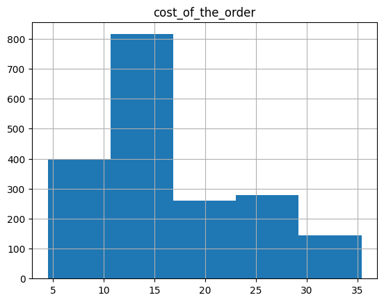

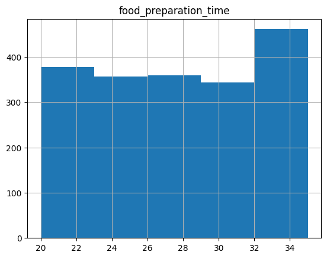

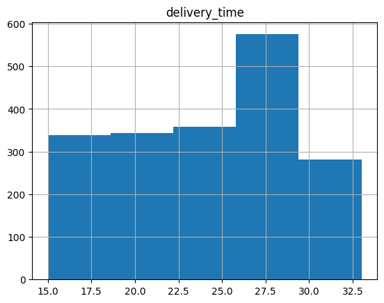

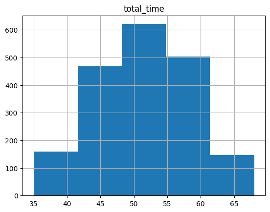

```
Univariate analysis of object (categorical) columns:
```

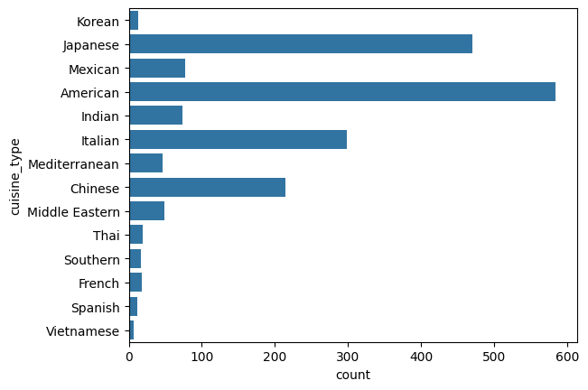

```
cuisine_type
American          584
Japanese          470
Italian           298
Chinese           215
Mexican            77
Indian             73
Middle Eastern     49
Mediterranean      46
Thai               19
French             18
Southern           17
Korean             13
Spanish            12
Vietnamese          7
Name: count, dtype: int64
```

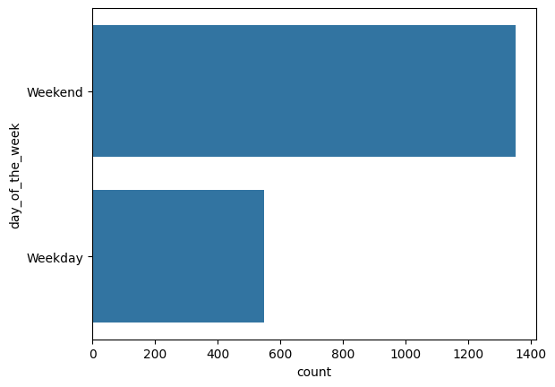

```
day_of_the_week
Weekend    1351
Weekday     547
Name: count, dtype: int64
```

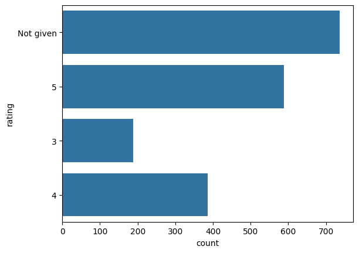

```
rating
Not given    736
5            588
4            386
3            188
Name: count, dtype: int64
```

```python
#calculating total time from order placed to food delivered, for univariate analysis
df['total_time'] = df['food_preparation_time']+df['delivery_time']


#separating dataframe columns into numerical and object
#numerical columns (excluding order id, customer id)
num_cols = ['cost_of_the_order','food_preparation_time',
            'delivery_time','total_time']

#describing numerical columns
print(df[num_cols].describe())

#object columns (excluding restaurant name)
obj_cols = ['cuisine_type','day_of_the_week','rating']

#looping numerical columns to show histogram distribution
print('\033[1mUnivariate analysis of numerical columns:\033[0m\n')
for x in num_cols:
    #setting number of bins to 10 after trial and error
    df.hist(x,bins=5)
    plt.show()

#looping object (categorical) columns to show countplot distribution
print('\033[1m\nUnivariate analysis of object (categorical) columns:\033[0m\n')
for x in obj_cols:
    #showing countplot of categories
    sns.countplot(df[x])
    plt.show()

    #printing table of values
    print(df[x].value_counts())
```